# Freva - Data search and analysis framework for the Community

# Setup

For this workshop we have two categories of the notebooks.

1. Shell script - The start with `Tutorial-shell-*.ipynb`
2. Python - The start with `Tutorial-py-*.ipynb`

First and foremost we need to decide to choose one of them. After choosing, please open the Terminal on a new tab on your Jupyterhub session and :

```
$ module load clint gems
$ da-workshop-setup
```

Now reload the Jupyterhub page please to make the avaiable kernels "selectable".

And afterward open the `Tutorial-py-search-cataloging.ipynb` or `Tutorial-shell-search-cataloging.ipynb`, based on your desire, and then from kernel environment list, please choose, `DA Workshop (python)` or `DA Workshop (shell)` based on the chosen language of the notebook.

Now all is set to start! :)

0

### Setup

### Initial Check

```python
export PATH=/sw/spack-levante/cdo-2.2.2-4z4icb/bin:$PATH
freva-client --version
```

```
freva-client: 2508.0.0
```

```python
from freva_client import databrowser, __version__
print(__version__)
```

```
2508.0.0
```

1

# Search (Findablity)

### MPI-GE (Grand Ensemble)

[figure not shown]

1

### Search

```python
$ freva-client databrowser data-overview
```

```
Available search flavours:
- freva
- cmip6
- cmip5
- cordex
- nextgems
- user
Search attributes by flavour:
  cmip5:
  - experiment
  - member_id
  - fs_type
  - grid_label
  - institution_id
  - model_id
  - project
118 more lines truncated
```

1

### Search

```python
databrowser.metadata_search(host="https://www.gems.dkrz.de").keys()
```

```
dict_keys(['ensemble', 'experiment', 'institute', 'model', 'product', 'project', 'realm', 'time_aggregation', 'time_frequency', 'variable'])
```

1

### Search

```python
$ freva-client databrowser metadata-search --host https://www.gems.dkrz.de \
--facet mpi-ge --json | jq -r 'to_entries[] | select(.value[] == "mpi-ge") \
| .key'
```

```
project
```

```python
$ freva-client databrowser metadata-search project=mpi-ge --json \
| jq -rc '.variable | index("tas") != null'
```

```
true
```

1

### Search

```python
metadata = databrowser.metadata_search("mpi-ge", host="https://www.gems.dkrz.de")
facets_with_mpi_ge = [facet for facet, values in metadata.items() if "mpi-ge" in values]
print(facets_with_mpi_ge)
```

```
['project']
```

```python
"tas" in databrowser.metadata_search("mpi-ge",
                                     host="https://www.gems.dkrz.de")["variable"]
```

```
True
```

1

### Search

```python
$ freva-client databrowser metadata-search --host www.gems.dkrz.de --flavour cmip6 \
mip_era=mpi-ge variable_id=tas --time '2025-01 to 2100-12'
```

```
member_id: r001i1850p3,  r001i2005p3,  r002i2005p3, ...
experiment_id: picontrol,  rcp26,  rcp45, ...
institution_id: mpi-m
source_id: mpi-esm
activity_id: output1
mip_era: mpi-ge
realm: atmos,  land, ...
time_aggregation: mean
frequency: mon
variable_id: tas
1 more lines truncated
```

1

### Search

```python
from freva_client import databrowser
db = databrowser(host="https://www.gems.dkrz.de",
                 flavour="cmip6",
                 mip_era="mpi-ge",
                 variable_id="tas",
                 time="2025-01 to 2100-12")
db
```

| databrowser(flavour=cmip6, host=https://www.gems.dkrz.de/api/freva-nextgen/databrowser, multi_version=False, mip_era=mpi-ge, variable_id=tas, time=2025-01 to 2100-12, time_select=flexible) |  |
| --- | --- |
| **# objects** | 602 |
| **Available search facets for *cmip6* flavour** | experiment_id, member_id, fs_type, grid_label, institution_id, source_id, mip_era, activity_id, realm, variable_id, time, bbox, time_aggregation, frequency, table_id, dataset, format, grid_id, level_t… |
| **Available flavours** | freva, cmip6, cmip5, cordex, nextgems, user |

1

### Search

[video not shown]

1

### Search

```python
$ freva-client databrowser metadata-search  --host www.gems.dkrz.de \
--flavour cmip6 mip_era=mpi-ge variable_id=tas --json \
|  /run/current-system/sw/bin/jq -c .frequency
```

```
["mon"]
```

```python
$ freva-client databrowser data-count  --host www.gems.dkrz.de --flavour cmip6 \
mip_era=mpi-ge frequency=mon variable_id=pr variable_id=tas \
time='2025-01 to 2100-12'
```

```
602
```

1

### Search

```python
db.metadata["frequency"]
```

```
['mon']
```

```python
db_yr =  databrowser(
    host="https://www.gems.dkrz.de",
    flavour="cmip6",
    mip_era="mpi-ge",
    frequency="mon",
    variable_id="tas",
    time="2025-01 to 2100-12"
)
len(db_yr)
```

```
602
```

1

### Search

```python
$ freva-client databrowser metadata-search mip_era=mpi-ge variable_id=tas \
frequency=mon --time "2025-01 to 2100-12" --json \
--host  https://www.gems.dkrz.de --flavour cmip6 \
 | jq -c ".experiment_id"
```

```
["picontrol","rcp26","rcp45","rcp85"]
```

```python
$ freva-client databrowser data-count mip_era=mpi-ge variable_id=tas \
frequency=mon --time "2025-01 to 2100-12" --json experiment_id=picontrol \
--host  https://www.gems.dkrz.de --flavour cmip6
```

```
2
```

```python
$ freva-client databrowser data-search mip_era=mpi-ge variable_id=tas \
frequency=mon --time "2025-01 to 2100-12" experiment_id=picontrol \
--host  https://www.gems.dkrz.de --flavour cmip6
```

```
/work/mh1007/CMOR/MPI-GE/output1/MPI-M/MPI-ESM/piControl/mon/atmos/tas/r001i1850p3/v20190123/tas_Amon_MPI-ESM_piControl_r001i1850p3_210001-219912.nc
/work/mh1007/CMOR/MPI-GE/output1/MPI-M/MPI-ESM/piControl/mon/atmos/tas/r001i1850p3/v20190123/tas_Amon_MPI-ESM_piControl_r001i1850p3_200001-209912.nc
```

1

### Search

```python
db_yr.metadata["experiment_id"]
```

```
['picontrol', 'rcp26', 'rcp45', 'rcp85']
```

```python
pcontrol = databrowser(mip_era="mpi-ge",
                       variable_id="tas",
                       frequency="mon", time="2025-01 to 2100-12", experiment_id="picontrol",
                       host="https://www.gems.dkrz.de", flavour="cmip6")
len(pcontrol)
```

```
2
```

```python
for num, file in enumerate(pcontrol):
    print(file)
    if num > 1:
        break
```

```
/work/mh1007/CMOR/MPI-GE/output1/MPI-M/MPI-ESM/piControl/mon/atmos/tas/r001i1850p3/v20190123/tas_Amon_MPI-ESM_piControl_r001i1850p3_210001-219912.nc
/work/mh1007/CMOR/MPI-GE/output1/MPI-M/MPI-ESM/piControl/mon/atmos/tas/r001i1850p3/v20190123/tas_Amon_MPI-ESM_piControl_r001i1850p3_200001-209912.nc
```

1

### Search

```
$ freva-client databrowser metadata-search file=/work/mh1007/CMOR/MPI-GE/output1/MPI-M/MPI-ESM/piControl/mon/atmos/tas/r001i1850p3/v20190123/tas_Amon_MPI-ESM_piControl_r001i1850p3_210001-219912.nc --host=www.gems.dkrz.de
```

```
ensemble: r001i1850p3
experiment: picontrol
institute: mpi-m
model: mpi-esm
product: output1
project: mpi-ge
realm: atmos
time_aggregation: mean
time_frequency: mon
variable: tas
```

1

### Search

```python
db.metadata_search(
    file="/work/mh1007/CMOR/MPI-GE/output1/MPI-M/MPI-ESM/piControl/mon/atmos/tas/r001i1850p3/v20190123/tas_Amon_MPI-ESM_piControl_r001i1850p3_210001-219912.nc",
    host="www.gems.dkrz.de"
)
```

```
{'ensemble': ['r001i1850p3'],
 'experiment': ['picontrol'],
 'institute': ['mpi-m'],
 'model': ['mpi-esm'],
 'product': ['output1'],
 'project': ['mpi-ge'],
 'realm': ['atmos'],
 'time_aggregation': ['mean'],
 'time_frequency': ['mon'],
 'variable': ['tas']}
```

1

### Search

```python
freva-client databrowser metadata-search mip_era=mpi-ge variable_id=tas \
frequency=mon --time="2025-01 to 2100-12"  experiment_id='!picontrol' --json \
--host https://www.gems.dkrz.de --flavour cmip6| jq -rc '.experiment_id| join(" ")'
```

```
rcp26 rcp45 rcp85
```

1

### Search

```python
db = databrowser(mip_era="mpi-ge", variable_id="tas",
                 frequency="mon", time="2025-01 to 2100-12",
                 experiment_id="!picontrol", flavour="cmip6",
                 host="https://www.gems.dkrz.de"
                )
db.metadata["experiment_id"]
```

```
['rcp26', 'rcp45', 'rcp85']
```

1

### Search

```python
temp_dir=$(mktemp -d --suffix cdo)
for exp in $experiments ;do
    outlist=()
    # Let's get only the first 5 ensemble member for brevity
    members=$(freva-client databrowser metadata-search \
    project=mpi-ge variable=tas time_frequency=mon --time="2025-01 to 2100-12" experiment="$exp" --json |
    jq -r '.ensemble | unique | .[:5] | join(" ")')
    for ens in $members;do
        echo -ne "Reading data and calculating TS for experiment $exp in ens: $ens\r"
        files=$(freva-client databrowser data-search project=mpi-ge variable=tas time_frequency=mon --time="2025-01 to 2100-12" experiment=$exp ensemble=$ens realm=atmos)
        outfile="$temp_dir/tas_mean_${exp}_${ens}.nc"
        cdo -s fldmean -mergetime $files "$outfile"
        outlist+=("$outfile")
    done
    cdo mergetime "${outlist[@]}" "$temp_dir/tas_ensemble_${exp}.nc"
done
cdo mergetime $temp_dir/tas_ensemble_*.nc tas_all_experiments.nc
```

```
cdo    mergetime: Processed 5640 values from 5 variables over 5640 timesteps [0.03s 25MB]
cdo    mergetime: Processed 5640 values from 5 variables over 5640 timesteps [0.03s 25MB]
cdo    mergetime: Processed 5640 values from 5 variables over 5640 timesteps [0.03s 25MB]
```

1

### Search

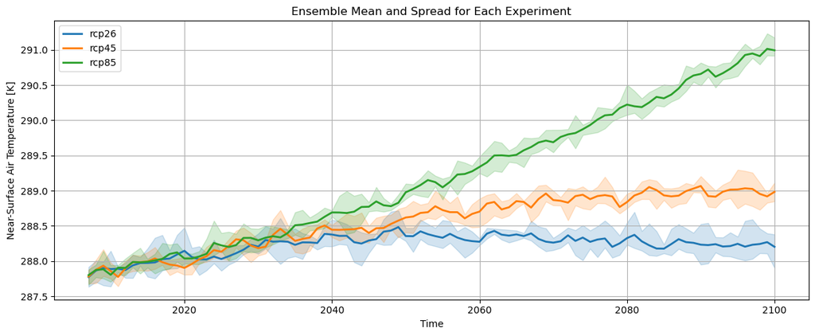

```python
import matplotlib.pyplot as plt

colors = plt.rcParams["axes.prop_cycle"].by_key()["color"]
plt.figure(figsize=(12, 5))

for i, exp in enumerate(data.experiment.values):
    ts = data.sel(experiment=exp).resample(time="1YE").mean()
    ts_min = ts.min(dim="ensemble").squeeze()
    ts_max = ts.max(dim="ensemble").squeeze()
    ts_mean = ts.mean(dim="ensemble").squeeze()
    plt.fill_between(
        ts.time,
        ts_min,
        ts_max,
        color=colors[i % len(colors)],
        alpha=0.2,
        label=None,
    )
    plt.plot(
        ts.time,
        ts_mean,
        color=colors[i % len(colors)],
        linewidth=2,
        label=f"{exp}"
    )
plt.title("Ensemble Mean and Spread for Each Experiment")
plt.xlabel("Time")
plt.ylabel(f"{data.attrs['long_name']} [{data.attrs['units']}]")
plt.legend()
plt.grid(True)
plt.tight_layout()
plt.show()
```

.

1

### Search

### Find data via STAC Browser

[video not shown]

2

# Cataloging Data (Reusablity)

```python
$ freva-client databrowser intake-catalogue  --host www.gems.dkrz.de --flavour cmip6 \
mip_era=mpi-ge frequency=mon variable_id=tas --time "2025-01 to 2100-12" \
experiment_id=picontrol
```

```
{
   "esmcat_version": "0.1.0",
   "attributes": [
      {
         "column_name": "mip_era",
         "vocabulary": ""
      },
      {
         "column_name": "activity_id",
         "vocabulary": ""
      },
      {
         "column_name": "institution_id",
         "vocabulary": ""
      },
      {
         "column_name": "source_id",
         "vocabulary": ""
      },
      {
         "column_name": "experiment_id",
         "vocabulary": ""
      },
      {
         "column_name": "frequency",
         "vocabulary": ""
      },
      {
         "column_name": "realm",
         "vocabulary": ""
      },
      {
         "column_name": "variable_id",
         "vocabulary": ""
      },
      {
         "column_name": "member_id",
         "vocabulary": ""
      },
      {
```

[output cut: 148 more lines]

[output not shown]

.

2

### Catalog

```python
db = databrowser(mip_era="mpi-ge", variable_id="tas",
                 frequency="mon", time="2025-01 to 2100-12",
                 experiment_id="picontrol", flavour="cmip6",
                 host="https://www.gems.dkrz.de"
                )
db.intake_catalogue()
```

**freva catalog with 2 dataset(s) from 2 asset(s)**:

|  | unique |
| --- | --- |
| file | 2 |
| project | 1 |
| product | 1 |
| institute | 1 |
| model | 1 |
| experiment | 1 |
| time_frequency | 1 |
| realm | 1 |
| variable | 1 |
| ensemble | 1 |
| cmor_table | 1 |
| fs_type | 1 |
| grid_label | 1 |
| format | 1 |
| derived_variable_id | 0 |

2

### Catalog

```python
$ freva-client databrowser stac-catalogue --host www.gems.dkrz.de --flavour cmip6 \
mip_era=mpi-ge frequency=mon variable_id=tas --time "2025-01 to 2100-12" \
experiment_id=picontrol
```

```
Downloading the STAC catalog started ...
STAC catalog saved to: /Users/mo/dev/20250805/Talks/talks/DataSearchWorkshop2025/stac-catalog-Dataset-cmip6-ca87bec5-e66-file.zip (size: 0.02 MB). Or simply download from: https://www.gems.dkrz.de/api/freva-nextgen/databrowser/stac-catalogue/cmip6/file?multi-version=False&mip_era=mpi-ge&frequency=mo…
```

2

### Catalog

```python
db = databrowser(mip_era="mpi-ge", variable_id="tas",
                 frequency="mon", time="2025-01 to 2100-12",
                 experiment_id="picontrol", flavour="cmip6",
                 host="https://www.gems.dkrz.de"
                )
db.stac_catalogue()
```

```
Downloading the STAC catalog started ...
```

```
'STAC catalog saved to: /Users/mo/dev/20250805/Talks/talks/DataSearchWorkshop2025/stac-catalog-Dataset-cmip6-ec013869-2c5-file.zip (size: 0.01 MB). Or simply download from: https://www.gems.dkrz.de/api/freva-nextgen/databrowser/stac-catalogue/cmip6/file?multi-version=False&mip_era=mpi-ge&variable_id…
```

2

### Catalog

[video not shown]

3

# Customize Dataset (Interoperablity)

To continue this section please open the `Tutorial-py-userdata.ipynb` or `Tutorial-shell-userdata.ipynb`, based on your desire, and then from kernel environment list, please choose, `DA Workshop (python)` or `DA Workshop (shell)` again based on your preferences.

3

### Custom

```python
USER=$(whoami)
OUTFILE="dummy_sst_${USER}.nc"
GRIDFILE="$(mktemp)"
cat > "$GRIDFILE" << EOF
gridtype = lonlat
xsize    = 171
ysize    = 121
xfirst   = 120
xinc     = 1
yfirst   = -30
yinc     = 0.5
xname    = lon
yname    = lat
xunits   = degrees_east
yunits   = degrees_north
EOF
cdo -f nc const,0,"$GRIDFILE" base.nc
cdo -f nc \
    -setcalendar,standard \
    -settaxis,2025-01-01,00:00:00,1month \
    -expr,'sst=28-0.006*(clon(const)-230)' \
    -setattribute,sst@long_name="Idealized Pacific SST" \
    -setattribute,sst@units="°C" \
    base.nc "$OUTFILE"
rm -f base.nc "$GRIDFILE"
echo "Wrote $OUTFILE → exists? $( [[ -f $OUTFILE ]] && echo yes || echo no )"
```

Wrote dummy_sst_k202187.nc → exists? yes

3

### Custom

```python
import numpy as np, xarray as xr, os
from getpass import getuser
from freva_client import databrowser, authenticate
from pathlib import Path
time = np.arange("2025-01","2026-01",dtype="datetime64[M]")
lat, lon = np.linspace(-30,30,121), np.linspace(120,290,171)
da = (xr.DataArray(28 - 0.006*(lon-230), dims=("lon",), coords={"lon":lon})
      .expand_dims(time=time, lat=lat))
da.name = "sst"; da.attrs.update(long_name="Idealized Pacific SST", units="°C")
da.to_netcdf(f"dummy_sst_{getuser()}.nc")
print(f"check if dummy_sst_{getuser()}.nc exists: {os.path.exists(f'dummy_sst_{getuser()}.nc')}")
```

```
check if dummy_sst_mo.nc exists: True
```

3

### Custom

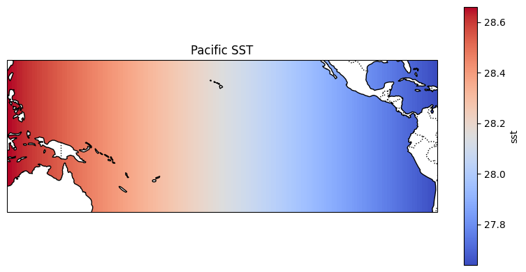

```python
import matplotlib.pyplot as plt, cartopy.crs as ccrs, cartopy.feature as cfeature

fig, ax = plt.subplots(figsize=(8,4), subplot_kw=dict(projection=ccrs.PlateCarree(180)))
da.mean("time").plot.pcolormesh(ax=ax, transform=ccrs.PlateCarree(), cmap="coolwarm", add_colorbar=True)

ax.add_feature(cfeature.LAND, facecolor="white", zorder=2); ax.coastlines(zorder=3); ax.add_feature(cfeature.BORDERS, linestyle=":", zorder=3)
plt.title("Pacific SST"); plt.tight_layout(); plt.show()
```

0

### Auth

```python
cat > ~/.freva-access-token.json << 'EOF'

EOF
```

```python
token = """ """
_ = (Path.home() / ".freva-access-token.json").write_text(token)
```

[video not shown]

3

### Custom

```python
global_attributes = {"project": "userdata", "product": "stats", "model": "IFS", "experiment": "ETCCDI", "realm": "atmos"}
databrowser.userdata(
    action="add",
    userdata_items=[f"{os.getcwd()}/dummy_sst_{getuser()}.nc"],
    metadata=global_attributes,
)
```

```
1 have been successfully added to the databrowser. 0 files were duplicates and not added.
```

```python
global_attributes = {"project": "userdata", "product": "stats", "model": "IFS", "experiment": "ETCCDI", "realm": "atmos"}
databrowser.userdata(
    action="delete",
    metadata=global_attributes,
)
```

```
User data deleted successfully
```

3

### Custom

```
$ freva-client databrowser user-data add --path dummy_sst_mo.nc --facet project=userdata --facet product=stats --facet model=IFS --facet experiment=ETCCDI --facet realm=atmos --token-file ~/.freva-access-token.json
```

```
1 have been successfully added to the databrowser. 0 files were duplicates and
not added.
```

```
$ freva-client databrowser user-data delete --search-key project=userdata --search-key product=stats --search-key model=IFS --search-key experiment=ETCCDI --search-key realm=atmos --token-file ~/.freva-access-token.json
```

```
User data deleted successfully
```

3

### Custom

[video not shown]

4

# S3 Access (Accessibility)

4

### S3

### File vs Object Storage

## File Storage

- Hierarchical structure (tree)
  - Directory with files and other directories
- Easy to rename and move items around
  - **Not** identified by name
  - Change references
- *System-centric*, not designed to be share

4

### S3

### File vs Object Storage

## Object Storage

- Flat structure (key-value)
  - Items are identified by a key/name
  - Content is accessed providing key/name
- Not easy to move items around!
  - Moving is renaming
  - Modify key

4

### S3

### Local vs Remote

**Local** storage should be:

- Fast
- Reliable
- Performant!

**Remote** storage should be:

- Simple & common language
- Permissive
- Highly available!

4

### S3

## HTTP aka internet language!?

Stands for *Hypertext Transfer Protocol*. There are many protocols...

- simple
- very generic
- very flexible
- famous!

Client makes a **request**, server **replies**

> *NOTE:* IP the actual and literal Internel Protocol

4

### S3

## Requests

- [Method](https://developer.mozilla.org/en-US/docs/Web/HTTP/Reference/Headers) - *verb*/type (`GET`, etc...)
- Headers - metadata, options (`Content-Type`,...)
- Body - data (empty, raw bytes, text,... )

4

### S3

## Replies

- [Status Code](https://developer.mozilla.org/en-US/docs/Web/HTTP/Reference/Status) -(`404 Not Found`)
- [Headers](https://developer.mozilla.org/en-US/docs/Glossary/Response_header) - metadata, options (`Content-Type`,...)
- Body - data (empty, raw bytes, text,... )

4

### S3

## Object Store APIs

Providers expose application programming interface (API) which might not be (**fully**) interchangable. E.g. `list objects`:

- [AWS S3](https://docs.aws.amazon.com/AmazonS3/latest/API/API_Operations_Amazon_Simple_Storage_Service.html)

```
GET /?delimiter={delimiter}&encoding-type={enctype}&marker=....&prefix={prefix}
```

- [Openstack Swift](https://docs.openstack.org/api-ref/object-store/#show-container-details-and-list-objects)

```
GET /v1/{account}/{container}
```

- [Google Cloud Storage](https://cloud.google.com/storage/docs/json_api/v1/objects/get)

```
GET /v1/b/{bucket}/o/
```

- [Azure Blob Storage](https://learn.microsoft.com/en-us/rest/api/storageservices/blob-service-rest-api)

```
GET /{container}?restype=container&comp=list
```

4

### S3

# S3 - Simple Storage Service

Created by AWS

- S3 API is public (partially)

4

### S3

## S3 Concepts

- Bucket - The container of the objects
- Objects - The actual data
- Regions (advanced) - Location of the data
- Authentication

> Directories can be emulated by empty objects terminated with `/`

4

### S3

## S3 - Authentication

- A bucket may not be publicly available.
- Key-Secret pairs sign the request
  - May expire automatically
  - May be valid indefinetly
- Create temporarly link to share or receive data

4

### S3

## Exploring data on S3

- Command line interfaces (CLIs)
- Software Development Kits (SDKs)
  - Libraries

4

### S3

## CLIs

AWS provides a command line interface (not just for `s3`)

```python
#conda install awscli ||pip install awscli
aws s3 ls s3://ncar-cesm2-lens/ --no-sign-request

alias awss3='aws s3 --no-sign-request'
awss3 cp --recursive  s3://ncar-cesm2-lens/atm/static/grid.zarr /tmp/grid.zarr
```

`s3://` is a comodity:

- `s3://ncar-cesm2-lens` resolves to `https://s3.us-west-2.amazonaws.com/ncar-cesm2-lens`
- Behaviour dependens on the `AWS_*` [environment variables](https://docs.aws.amazon.com/cli/v1/userguide/cli-configure-envvars.html)

> Appending `/` to the S3 resource may produce different results

4

### S3

## MINIO

[Minio](https://docs.min.io/community/minio-object-store/index.html) - Open source S3 object store

Provides both CLI and SDKs! Available [playground](https://docs.min.io/community/minio-object-store/developers/python/minio-py.html#id3)

```python
module load minio-client
mc alias set aws https://s3.amazonaws.com "" "" # empty keys = no authentication
mc ls aws/ncar-cesm2-lens/ice/static/grid.zarr

mc alias set dkrz https://s3.eu-dkrz-1.dkrz.cloud "" "" # no authentication ->  read-only!!!
mc ls dkrz/freva
#mc cp /scratch/${USER:0:1}/${USER}/path/to/my/file.txt dkrz/freva/workshop/${USER}/myfile.txt
```

4

### S3

## Useful Python modules

- [`boto3`](https://boto3.amazonaws.com/v1/documentation/api/latest/index.html) - AWS S3 official sdk for python
  - [`aioboto3`](https://github.com/terricain/aioboto3)
- [`obstore`](https://developmentseed.org/obstore/latest/api/store/#obstore.store.from_url) - Also supports non S3 object stores
- [`fsspec`](https://github.com/fsspec)/[`s3fs`](https://github.com/fsspec/s3fs) - Filesystem wrapper for storage types
- [`minio`](https://min.io/docs/minio/linux/developers/python/minio-py.html) - Minio SDK for python

4

### S3

## The usual suspects

```python
dataset_url = 's3://ncar-cesm2-lens/ocn/static/grid.zarr'
s3_opts = {'anon': True }
# s3_minio_opt = { # From playground:  https://docs.min.io/community/minio-object-store/developers/python/minio-py.html#id3
#     'key': 'Q3AM3UQ867SPQQA43P2F',
#     'secret': 'zuf+tfteSlswRu7BJ86wekitnifILbZam1KYY3TG',
#     'client_kwargs':{'endpoint_url': 'https://play.min.io'}
# }
```

```python
import xarray as xr
ds = xr.open_dataset(dataset_url, engine='zarr', storage_options=s3_opts)
```

```python
import zarr
zarr.open(dataset_url, storage_options=s3_opts)
```

4

### S3

## NetCDF on S3 (classic, nc4/hdf5)

```python
import s3fs
s3 = s3fs.S3FileSystem(endpoint_url="https://s3.eu-dkrz-1.dkrz.cloud", anon=True)
with s3.open('s3://freva/workshop/tas.nc') as f:
    ds = xr.open_dataset(f)
```

We **cannot** write directly via `xarray`. The reason is that Netcdf jumps back and forth while writing the file, which is not supported by S3.

Instead, we can write to a file or memory buffer which we then upload to S3.

In Levante custom builds of `libnetcdf` and `cdo` can work with data on S3

> Very unstable!!!

```
/fastdata/freva/opt/bin/ncdump  -h https://s3.eu-dkrz-1.dkrz.cloud/freva/workshop/tas.nc#mode=s3,bytes
/fastdata/freva/opt/bin/cdo  sinfo https://s3.eu-dkrz-1.dkrz.cloud/freva/workshop/tas.nc#mode=s3,bytes
```

4

### S3 Handson

# Handson - S3 Data Access

For this part we have a single `python` the notebook.

Assuming you previously executed the setup stetps:

```
$ module load clint gems
$ da-workshop-setup
```

Open the `Tutorial-py-s3.ipynb` and then from kernel environment list, please choose, `DA Workshop (python)`.

Let's then start! :)

4

### S3 Handson

```python
strip_dict(databrowser.metadata_search(fs_type="s3"))
```

```
{'ensemble': ['r1i1p1f1'],
 'experiment': ['historical', 'ssp370'],
 'institute': ['ncar'],
 'model': ['cesm2-le'],
 'product': ['output'],
 'project': ['cesm2-le'],
 'realm': ['atm', 'ice', 'lnd', '...'],
 'time_aggregation': ['mean'],
 'time_frequency': ['daily', 'monthly', 'static'],
 'variable': ['aice', 'aice_d', 'dic', '...']}
```

4

### S3 Handson

```python
search_keys = {
    'fs_type': 's3',
    'project':'cesm2-le',
    'experiment': 'historical',
    'realm': 'atm',
    'time_frequency':'monthly'
}
'ts' in databrowser.metadata_search(**search_keys)['variable']
```

```
True
```

```python
db = databrowser(variable='ts', **search_keys)
list(db)
```

```
['s3://ncar-cesm2-lens/atm/monthly/cesm2LE-historical-smbb-TS.zarr',
 's3://ncar-cesm2-lens/atm/monthly/cesm2LE-historical-cmip6-TS.zarr']
```

4

### S3 Handson

## Let's quickly check how to open the first dataset with xarray

Since all are zarr datasets we can use `xr.open_zarr` or `xr.open_dataset(engine='zarr')`.

Because the data is public, we do not need credentials to open the data. We specify `anon` (anonymous) in order for xarray to not sign the requests.

If data is **not** public we will get `403 Forbidden`

4

### S3 Handson

```python
import xarray as xr
xr.open_zarr(list(db)[0], storage_options={ 'anon':True })
print(xr.open_dataset(list(db)[0], engine='zarr', storage_options={ 'anon':True }))
```

```
<xarray.Dataset> Size: 22GB
Dimensions:    (member_id: 50, time: 1980, lat: 192, lon: 288, nbnd: 2)
Coordinates:
  * lat        (lat) float64 2kB -90.0 -89.06 -88.12 ... 88.12 89.06 90.0
  * lon        (lon) float64 2kB 0.0 1.25 2.5 ... 355.0 356.2 357.5 358.8
  * member_id  (member_id) <U12 2kB 'r10i1191p1f2' ... 'r9i1171p1f2'
  * time       (time) object 16kB 1850-01-16 12:00 ... 2014-12-16 12:00:00
    time_bnds  (time, nbnd) object 32kB ...
Dimensions without coordinates: nbnd
Data variables:
    TS         (member_id, time, lat, lon) float32 22GB ...
Attributes:
    Conventions:       CF-1.0
    logname:           sunseon
    model_doi_url:     https://doi.org/10.5065/D67H1H0V
    source:            CAM
    time_period_freq:  month_1
    topography_file:   /mnt/lustre/share/CESM/cesm_input/atm/cam/topo/fv...
```

4

### S3 Handson

```python
from pathlib import Path
s3_opts = { 'anon':True }
time_series = {}

for fileurl in db:
    print(f"Opening {fileurl}...")
    engine = {'engine':'zarr'} if fileurl.endswith('zarr') else {}
    ds = xr.open_dataset(fileurl, **engine, storage_options=s3_opts)
    ds = ds.rename({'member_id':'ensemble'})

    # Going through all ensembles might take some time
    # let's make a cut at 5 member for demo purposes
    # Memory usage might spike to ~70GB
    members=ds.ensemble[:5]
    ds = ds.sel(ensemble=members)

    # cesm2LE-historical-cmip6-TS cesm2LE-historical-smbb-TS
    dataset_name=Path(fileurl).stem

    mean_ts = field_mean(ds["TS"])
    mean_ts.attrs['source_dataset'] = fileurl
    time_series[dataset_name] = mean_ts
```

```
Opening s3://ncar-cesm2-lens/atm/monthly/cesm2LE-historical-smbb-TS.zarr
Opening s3://ncar-cesm2-lens/atm/monthly/cesm2LE-historical-cmip6-TS.zarr
```

4

### S3 Handson

Plot the data (same as before)

[figure not shown]

4

### S3 Handson

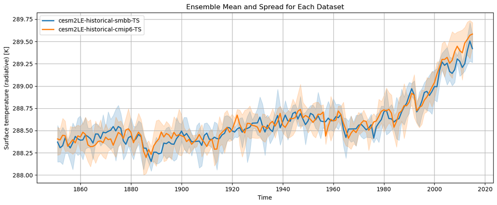

```python
import matplotlib.pyplot as plt

# Create a color cycle for different experiments
colors = plt.rcParams["axes.prop_cycle"].by_key()["color"]

plot = plt.figure(figsize=(12, 5))

for i, (exp, data) in enumerate(time_series.items()):
    ts = data.resample(time="1YE").mean()
    ts_min = ts.min(dim="ensemble").squeeze()
    ts_max = ts.max(dim="ensemble").squeeze()
    ts_mean = ts.mean(dim="ensemble").squeeze()
    time_values = np.array(ts.time.values, dtype='datetime64[ns]')
    # Plot min–max shading
    plt.fill_between(
        time_values,
        ts_min.values,
        ts_max.values,
        color=colors[i % len(colors)],
        alpha=0.2,
        label=None,
    )
    # Plot mean line
    plt.plot(
        time_values,
        ts_mean.values,
        color=colors[i % len(colors)],
        linewidth=2,
        label=f"{exp}"
    )

# Add plot decorations
plt.title("Ensemble Mean and Spread for Each Dataset")
plt.xlabel("Time")
plt.ylabel(f"{data.attrs['long_name']} [{data.attrs['units']}]")  # Replace with actual units
plt.legend()
plt.grid(True)
plt.tight_layout()
plt.show()
```

4

### S3 Handson

# Let's save the plot on S3, as well as the datasets!

4

### S3 Handson

We start by setting up a dictionary with the configuration we will need!

```python
from getpass import getuser # to get USER env variable
USERNAME = getuser()
s3_config = {
    'bucket' : 'freva',
    'endpoint' :'https://s3.eu-dkrz-1.dkrz.cloud', # DKRZ Minio S3
    'prefix' : f'workshop/{USERNAME}', # Avoid users writting object with same prefix
    'access_key_id' : "s3handson", # Only valid during the workshop
    'secret_access_key' : "s3handson", # Only valid during the workshop
    'region' : 'eu-dkrz-1',
}
```

4

### S3 Handson

Now we create a wrapper on S3 that mimics a local filesystem. This will be important for `netcdf`

```python
import s3fs
s3 = s3fs.S3FileSystem(
    key = s3_config['access_key_id'],
    secret = s3_config['secret_access_key'],
    client_kwargs = {'endpoint_url': s3_config['endpoint']},
)
```

```python
full_prefix = s3_config['bucket']+'/'+s3_config['prefix']
testobj = f'{full_prefix}/hi.txt'
s3.write_bytes(testobj, b'Hi!\n')

print(f"Writing data to S3 works! Test it with:\ncurl {s3_config['endpoint']}/{testobj}")
```

```
Writing data to S3 works! Test it with:
curl https://s3.eu-dkrz-1.dkrz.cloud/freva/workshop/k202186/hi.txt
```

```python
!curl https://s3.eu-dkrz-1.dkrz.cloud/freva/workshop/${USER}/hi.txt
```

```
Hi!
```

4

### S3 Handson

### Save the figure on S3

- Open the object ("file") on S3 where the figure should be saved
- Save the figure into that opened object!

```python
figure_path = f'{full_prefix}/figure-ts-mean.png'
with s3.open(figure_path, 'wb') as f:
    plot.savefig(f)
print(f"Open this link to get the image: {s3_config['endpoint']}/{figure_path}")
```

```
Open this link to get the image: https://s3.eu-dkrz-1.dkrz.cloud/freva/workshop/k202186/figure-ts-mean.png
```

4

### S3 Handson

### Let's now write the data to S3 as both NetCDF and ZARR

Since we are writting to an object store we cannot pass an opened file to `xr.to_netcdf` because it will use `seek` operations, which are not allowed in S3!

In that case that case simply copy the file. For zarr it's ok because `seek` is not used.

```python
def write_netcdf(s3_path, dataset:xr.Dataset):
    tmp_name = f"/scratch/{USERNAME[0]}/{USERNAME}/{name}.nc"

    dataset.to_netcdf(tmp_name, engine='h5netcdf')

    ## Copy to s3
    with s3.open(s3_path,'wb') as s3file:
        with open(tmp_name, 'rb') as tmpf:
            s3file.write(tmpf.read())

    ## Check if we can open with Xarray!
    with s3.open(s3_path,'rb') as s3file:
        xr.open_dataset(s3file, engine='h5netcdf')

    ## We can now remove the local copy
    import os
    os.remove(tmp_name)
```

4

### S3 Handson

With Zarr is enough to pass the S3 configuration in order to have xarray writing the dataset

```python
def write_zarr(store, dataset: xr.Dataset):
    import zarr
    zarr.config.set(default_zarr_format=2)

    import numcodecs
    codec = numcodecs.Blosc(shuffle=1, clevel=6)

    data_encoding = {}
    for var in dataset.variables:
        data_encoding[var] = { "compressors": codec}

    dataset.to_zarr(store,
                    mode='w', # OVERWRITES existing data!!
                    encoding=data_encoding,
                    consolidated=True, # consolidate metadata for fast access
                    storage_options= { # We cannot use the anonymous mode anymore
                        'key':s3_config['access_key_id'],
                        'secret':s3_config['secret_access_key'],
                        'client_kwargs':{
                            'endpoint_url': s3_config['endpoint']
                        },
                    })
```

4

### S3 Handson

```python
def write_dataset_to_s3(name:str, dataset:xr.Dataset, file_format='nc'):
    _supported_types = ('nc','zarr')
    file_format = file_format.replace('.','')
    if file_format not in _supported_types:
        raise Exception('Unsuported file format, use one of')

    s3_path = f'{full_prefix}/{name}.{file_format}'
    if file_format == 'nc':
        write_netcdf(s3_path, dataset)

    elif file_format == 'zarr':
        write_zarr(f's3://{s3_path}', dataset)

    netcdf_mode= 'zarr' if file_format == 'zarr' else 'bytes'
    print(f"Try running:\n\t" \
          f"/fastdata/freva/opt/bin/ncdump -h {s3_config['endpoint']}/{s3_path}#mode=s3,{netcdf_mode}\n\t"\
          f"/fastdata/freva/opt/bin/cdo sinfo {s3_config['endpoint']}/{s3_path}#mode=s3,{netcdf_mode}")
```

4

### S3 Handson

We save the mean temperature array in S3 as both Zarr and NetCDF

```python
for name, data in time_series.items():
    ## for CDO it is important that time is the first dimension
    ## also it cannot have indexers of type string
    ensemble = data.ensemble.values
    ensemble_id = np.arange(len(ensemble))

    dataset = data.to_dataset() \
            .transpose('time',...) \
            .assign_coords(ensemble_id=('ensemble',ensemble_id)) \
            .swap_dims({'ensemble':'ensemble_id'}) \
            .reset_coords(drop=True)\
            .assign_attrs(ensembles= ', '.join(data.ensemble.values))

    write_dataset_to_s3(name, dataset, file_format='nc')
    write_dataset_to_s3(name, dataset, file_format='zarr')

public_url = f"https://eu-dkrz-1.dkrz.cloud/browser/{s3_config['bucket']}/{s3_config['prefix']}"
f"{s3_config['endpoint']}/browser/{s3_config['bucket']}/{s3_config['prefix']}"
print(f"Browser the data in {public_url}")
```

```
Try running:
	/fastdata/freva/opt/bin/ncdump -h https://s3.eu-dkrz-1.dkrz.cloud/freva/workshop/k202186/cesm2LE-historical-smbb-TS.nc#mode=s3,bytes
...
Browser the data in https://eu-dkrz-1.dkrz.cloud/browser/freva/workshop/k202186
```

4

### S3 Handson

As the output suggests, we should be able to see the contents of the bucket:

- https://eu-dkrz-1.dkrz.cloud/browser/freva/workshop/

Also, note the diference between endpoints:

- `eu-dkrz-1.dkrz.cloud` is for the web user interface
- `s3.eu-dkrz-1.dkrz.cloud` is for the data access

With a custom netcdf build (`/fastdata/freva/opt`), we can pass an URL with fragment `mode`:

- `s3` for any link that is an S3 URL
- `bytes` for raw netcdf data
- `zarr` for zarr data

E.g.:

```
export PATH=/fastdata/freva/opt/bin/:${PATH}
ncdump -h https://s3.eu-dkrz-1.dkrz.cloud/freva/workshop/tas.nc#mode=s3,bytes
ncdump -h https://s3.eu-dkrz-1.dkrz.cloud/freva/workshop/tas.zarr#mode=s3,zarr
```

4

### S3 Handson

```python
!/fastdata/freva/opt/bin/ncdump -h https://s3.eu-dkrz-1.dkrz.cloud/freva/workshop/$USER/cesm2LE-historical-smbb-TS.nc#mode=s3,bytes
!/fastdata/freva/opt/bin/cdo sinfo https://s3.eu-dkrz-1.dkrz.cloud/freva/workshop/$USER/cesm2LE-historical-smbb-TS.nc#mode=s3,bytes
```

```
netcdf cesm2LE-historical-smbb-TS {
dimensions:
	time = 1980 ;
	ensemble_id = 5 ;
variables:
	double time(time) ;
		time:_FillValue = NaN ;
		string time:units = "days since 1850-01-01" ;
		string time:calendar = "noleap" ;
	double TS(time, ensemble_id) ;
		TS:_FillValue = NaN ;
		string TS:cell_methods = "time: mean" ;
		string TS:long_name = "Surface temperature (radiative)" ;
		string TS:units = "K" ;
		string TS:source_dataset = "s3://ncar-cesm2-lens/atm/monthly/cesm2LE-historical-smbb-TS.zarr" ;
	int64 ensemble_id(ensemble_id) ;

// global attributes:
		string :ensembles = "r10i1191p1f2, r11i1231p1f2, r11i1251p1f2, r11i1281p1f2, r11i1301p1f2" ;
}
   File format : NetCDF4
    -1 : Institut Source   T Steptype Levels Num    Points Num Dtype : Parameter ID
     1 : unknown  unknown  v instant       1   1         5   1  F64  : -1
   Grid coordinates :
     1 : generic                  : points=5
                      ensemble_id : 0 to 4 by 1
   Vertical coordinates :
     1 : surface                  : levels=1
   Time coordinate :
                             time : 1980 steps
     RefTime =  1850-01-01 00:00:00  Units = days  Calendar = 365_day
  YYYY-MM-DD hh:mm:ss  YYYY-MM-DD hh:mm:ss  YYYY-MM-DD hh:mm:ss  YYYY-MM-DD hh:mm:ss
  1850-01-16 12:00:00  1850-02-15 00:00:00  1850-03-16 12:00:00  1850-04-16 00:00:00
  1850-05-16 12:00:00  1850-06-16 00:00:00  1850-07-16 12:00:00  1850-08-16 12:00:00
  1850-09-16 00:00:00  1850-10-16 12:00:00  1850-11-16 00:00:00  1850-12-16 12:00:00
  1851-01-16 12:00:00  1851-02-15 00:00:00  1851-03-16 12:00:00  1851-04-16 00:00:00
  1851-05-16 12:00:00  1851-06-16 00:00:00  1851-07-16 12:00:00  1851-08-16 12:00:00
  1851-09-16 00:00:00  1851-10-16 12:00:00  1851-11-16 00:00:00  1851-12-16 12:00:00
  1852-01-16 12:00:00  1852-02-15 00:00:00  1852-03-16 12:00:00  1852-04-16 00:00:00
  1852-05-16 12:00:00  1852-06-16 00:00:00  1852-07-16 12:00:00  1852-08-16 12:00:00
```

[output cut: 11 more lines]

```
  2010-05-16 12:00:00  2010-06-16 00:00:00  2010-07-16 12:00:00  2010-08-16 12:00:00
  2010-09-16 00:00:00  2010-10-16 12:00:00  2010-11-16 00:00:00  2010-12-16 12:00:00
  2011-01-16 12:00:00  2011-02-15 00:00:00  2011-03-16 12:00:00  2011-04-16 00:00:00
  2011-05-16 12:00:00  2011-06-16 00:00:00  2011-07-16 12:00:00  2011-08-16 12:00:00
  2011-09-16 00:00:00  2011-10-16 12:00:00  2011-11-16 00:00:00  2011-12-16 12:00:00
  2012-01-16 12:00:00  2012-02-15 00:00:00  2012-03-16 12:00:00  2012-04-16 00:00:00
  2012-05-16 12:00:00  2012-06-16 00:00:00  2012-07-16 12:00:00  2012-08-16 12:00:00
  2012-09-16 00:00:00  2012-10-16 12:00:00  2012-11-16 00:00:00  2012-12-16 12:00:00
  2013-01-16 12:00:00  2013-02-15 00:00:00  2013-03-16 12:00:00  2013-04-16 00:00:00
  2013-05-16 12:00:00  2013-06-16 00:00:00  2013-07-16 12:00:00  2013-08-16 12:00:00
  2013-09-16 00:00:00  2013-10-16 12:00:00  2013-11-16 00:00:00  2013-12-16 12:00:00
  2014-01-16 12:00:00  2014-02-15 00:00:00  2014-03-16 12:00:00  2014-04-16 00:00:00
  2014-05-16 12:00:00  2014-06-16 00:00:00  2014-07-16 12:00:00  2014-08-16 12:00:00
  2014-09-16 00:00:00  2014-10-16 12:00:00  2014-11-16 00:00:00  2014-12-16 12:00:00
cdo    sinfo: Processed 1 variable over 1980 timesteps [0.13s 3000MB]
```

4

### S3 Handson

```python
!/fastdata/freva/opt/bin/ncdump -h https://s3.eu-dkrz-1.dkrz.cloud/freva/workshop/$USER/cesm2LE-historical-smbb-TS.zarr#mode=s3,zarr
!/fastdata/freva/opt/bin/cdo sinfo https://s3.eu-dkrz-1.dkrz.cloud/freva/workshop/$USER/cesm2LE-historical-smbb-TS.zarr#mode=s3,zarr
```

```
netcdf cesm2LE-historical-smbb-TS {
dimensions:
	time = 1980 ;
	ensemble_id = 5 ;
variables:
	double TS(time, ensemble_id) ;
		TS:_FillValue = NaN ;
		TS:cell_methods = "time: mean" ;
		TS:long_name = "Surface temperature (radiative)" ;
		TS:units = "K" ;
		TS:source_dataset = "s3://ncar-cesm2-lens/atm/monthly/cesm2LE-historical-smbb-TS.zarr" ;
	int64 time(time) ;
		time:units = "hours since 1850-01-16 12:00:00.000000" ;
		time:calendar = "noleap" ;
	int64 ensemble_id(ensemble_id) ;

// global attributes:
		:ensembles = "r10i1191p1f2, r11i1231p1f2, r11i1251p1f2, r11i1281p1f2, r11i1301p1f2" ;
}
   File format : NCZarr filter
    -1 : Institut Source   T Steptype Levels Num    Points Num Dtype : Parameter ID
     1 : unknown  unknown  v instant       1   1         5   1  F64f : -1
   Grid coordinates :
     1 : generic                  : points=5
                      ensemble_id : 0 to 4 by 1
   Vertical coordinates :
     1 : surface                  : levels=1
   Time coordinate :
                             time : 1980 steps
     RefTime =  1850-01-16 12:00:00  Units = hours  Calendar = 365_day
  YYYY-MM-DD hh:mm:ss  YYYY-MM-DD hh:mm:ss  YYYY-MM-DD hh:mm:ss  YYYY-MM-DD hh:mm:ss
  1850-01-16 12:00:00  1850-02-15 00:00:00  1850-03-16 12:00:00  1850-04-16 00:00:00
  1850-05-16 12:00:00  1850-06-16 00:00:00  1850-07-16 12:00:00  1850-08-16 12:00:00
  1850-09-16 00:00:00  1850-10-16 12:00:00  1850-11-16 00:00:00  1850-12-16 12:00:00
  1851-01-16 12:00:00  1851-02-15 00:00:00  1851-03-16 12:00:00  1851-04-16 00:00:00
  1851-05-16 12:00:00  1851-06-16 00:00:00  1851-07-16 12:00:00  1851-08-16 12:00:00
  1851-09-16 00:00:00  1851-10-16 12:00:00  1851-11-16 00:00:00  1851-12-16 12:00:00
  1852-01-16 12:00:00  1852-02-15 00:00:00  1852-03-16 12:00:00  1852-04-16 00:00:00
  1852-05-16 12:00:00  1852-06-16 00:00:00  1852-07-16 12:00:00  1852-08-16 12:00:00
  1852-09-16 00:00:00  1852-10-16 12:00:00  1852-11-16 00:00:00  1852-12-16 12:00:00
```

[output cut: 10 more lines]

```
  2010-05-16 12:00:00  2010-06-16 00:00:00  2010-07-16 12:00:00  2010-08-16 12:00:00
  2010-09-16 00:00:00  2010-10-16 12:00:00  2010-11-16 00:00:00  2010-12-16 12:00:00
  2011-01-16 12:00:00  2011-02-15 00:00:00  2011-03-16 12:00:00  2011-04-16 00:00:00
  2011-05-16 12:00:00  2011-06-16 00:00:00  2011-07-16 12:00:00  2011-08-16 12:00:00
  2011-09-16 00:00:00  2011-10-16 12:00:00  2011-11-16 00:00:00  2011-12-16 12:00:00
  2012-01-16 12:00:00  2012-02-15 00:00:00  2012-03-16 12:00:00  2012-04-16 00:00:00
  2012-05-16 12:00:00  2012-06-16 00:00:00  2012-07-16 12:00:00  2012-08-16 12:00:00
  2012-09-16 00:00:00  2012-10-16 12:00:00  2012-11-16 00:00:00  2012-12-16 12:00:00
  2013-01-16 12:00:00  2013-02-15 00:00:00  2013-03-16 12:00:00  2013-04-16 00:00:00
  2013-05-16 12:00:00  2013-06-16 00:00:00  2013-07-16 12:00:00  2013-08-16 12:00:00
  2013-09-16 00:00:00  2013-10-16 12:00:00  2013-11-16 00:00:00  2013-12-16 12:00:00
  2014-01-16 12:00:00  2014-02-15 00:00:00  2014-03-16 12:00:00  2014-04-16 00:00:00
  2014-05-16 12:00:00  2014-06-16 00:00:00  2014-07-16 12:00:00  2014-08-16 12:00:00
  2014-09-16 00:00:00  2014-10-16 12:00:00  2014-11-16 00:00:00  2014-12-16 12:00:00
cdo    sinfo: Processed 1 variable over 1980 timesteps [0.10s 3000MB]
```

4

### S3 Handson

```python
print("Opening")
for name in time_series.keys():
    file = f'https://s3.eu-dkrz-1.dkrz.cloud/freva/workshop/{USERNAME}/{name}'
    print(f"{file}.nc\n{file}.zarr")
    xr.open_dataset(f'{file}.nc', engine='h5netcdf')
    xr.open_zarr(f'{file}.zarr')

print('All output datasets opened!')
```

```
Opening
https://s3.eu-dkrz-1.dkrz.cloud/freva/workshop/k202186/cesm2LE-historical-smbb-TS.nc
https://s3.eu-dkrz-1.dkrz.cloud/freva/workshop/k202186/cesm2LE-historical-smbb-TS.zarr
https://s3.eu-dkrz-1.dkrz.cloud/freva/workshop/k202186/cesm2LE-historical-cmip6-TS.nc
https://s3.eu-dkrz-1.dkrz.cloud/freva/workshop/k202186/cesm2LE-historical-cmip6-TS.zarr
All output datasets opened!
```

# After this walkthrough, we believe FREVA is FAIR enough!

Findable

Accessible

Interoperable

Reusable

What do you think?

# Wrap-up

### What we couldn't cover today

- Add your Data Analysis code:
  - Freva helps you to create UI's for Web, CLI and python
  - Reproduciple
  - Shareable
- AI tools such as frevaGPT (sneak peek via: gems.dkrz.de/chatbot)

### Wrap-up

## What is FrevaGPT? (pre-Beta!)

- 🤖 **FrevaGPT** is an AI assistant built into the Freva ecosystem. It uses large language models (LLMs) like GPT-4 alongside a live Python interpreter.
- ⚙️ It runs code directly on hybrid CPU/GPU nodes at DKRZ's Levante, operating on real data!
- ⚙️ It is also integrated with JupyterAI frontend for extended functionality with jupyterhub.
- 🚀 It serves as a powerful **stepping stone** to explore and analysis data using Freva.

➤ You can currently try it at: https://gems.dkrz.de/chatbot/

[figure not shown]

# Useful Info

[Jupyter notebooks for this workshop](https://github.com/freva-org/Talks/tree/main/talks/DataSearchWorkshop2025): `Tutorial-{I,II,III}-*.ipynb`

[Collection of related presentations](https://freva-org.github.io/Talks/)

[Freva documentation](https://freva-org.github.io/freva-nextgen/) and [GitHub repo](https://github.com/freva-org/)

Open instances of Freva at DKRZ:

| hostname | command (levante) | obs |
| --- | --- | --- |
| https://gems.dkrz.de | `module load clint gems` | only data browser |
| https://freva.dkrz.de | `module load clint freva` | with **plugins** ⚠️Need to add batch scheduling info in `Extra scheduler options`⚠️ |

# To reach us out, please write at freva@dkrz.de